# R Notebook

```r
ches_brigandine_RA <- function(taxlevel, broadlevel, broadkeep, ns = nonSpikes20, min = NA, max = NA, thresh = 10^6){
  minCpL <- min # 4
  maxCpL <- max # 7.5

  taxlevel <- enquo(taxlevel)
  broadlevel <- enquo(broadlevel)
  ns_loc0 <- aglom(!!taxlevel, !!broadlevel, ns)
  ns_loc <- ns_loc0 %>%
    filter(!!broadlevel %in% broadkeep)

  attached_loc <- find_attached(ns_loc, threshold = thresh)

  ## Pre plotting

  toPlot <- ns_loc %>%
    ungroup() %>%
    arrange(-Size_Class) %>% # this stops working with more than one phylum # are there NA values?
    filter(!!taxlevel %in% attached_loc) %>%
    mutate(RA = case_when(
      log10(RA) > maxCpL ~ 10^(maxCpL),
      log10(RA) < minCpL ~ 10^(minCpL),
      TRUE ~ RA
    )) %>%
    mutate(!!quo_name(taxlevel) := fct_rev(!!taxlevel))

  toPlotFree <- toPlot %>% filter(Size_Class == 0.2)
  toPlotAttached <- toPlot %>% filter(Size_Class >= 1.2)

  # Plotting

  # set breaks and labels
  if(is.na(minCpL)){minCpL = log10(min(toPlot$RA))}
  if(is.na(maxCpL)){maxCpL = log10(max(toPlot$RA))}
  loc_breaks = seq(from = minCpL, to = maxCpL, by = 1)
  loc_labels = loc_breaks
  if(!is.na(min)){loc_labels[1] = paste0("≤", loc_labels[1])}
  if(!is.na(max)){loc_labels[length(loc_labels)] = paste0("≥", loc_labels[length(loc_labels)])}


  # main
  locPlot <- toPlot %>%
  ggplot() +
  geom_point(shape = 22, color = "black", stroke = .5, size = 12, data = toPlotFree,
             aes(x = as.factor(Station), y = !!taxlevel, fill = log10(RA))) +
  geom_point(shape = 21, color = "black", stroke = .5, data = toPlotAttached,
             aes(x = as.factor(Station), y = !!taxlevel, fill = log10(RA), size = sqrt(Size_Class))) +

  scale_radius(breaks = sqrt(c(1.2, 5, 20, 53, 180, 500)), labels = c(1.2, 5, 20, 53, 180, 500), range = c(1, 10)) +
  scale_fill_viridis_c(breaks = loc_breaks, labels = loc_labels) +
  facet_grid(rows = vars(!!broadlevel), cols= vars(Depth), drop = TRUE, scales = "free", space = "free") +
  labs(y = quo_name(taxlevel), x = "Station", size = "Size Class", fill = "log10(RA)") +
  theme_bw() +
    theme(strip.text.y = element_text(angle = 0))

  locPlot
  #list(toPlotFree, toPlotAttached)
}
```

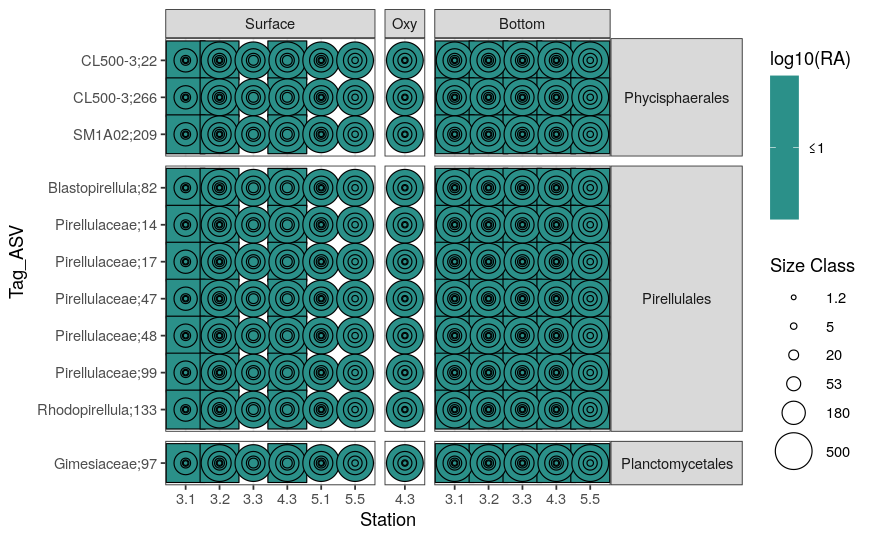

```r
ches_brigandine_RA(Tag_ASV, Order, taxa01 %>% filter(Phylum == "Planctomycetes") %>% pull(Order) %>% unique() %>% na.omit(), thresh = 10^6, min = 1)
```

# 20 October 2022

Looking for sulfate reducers and methanogenes

```r
source(here("RLibraries", "ChesapeakePersonalLibrary.R"))
env1 <- attach(here("RDataFiles", "InitialProcessing_3.RData"))
nonSpikes20 <- env1$nonSpikes20
nonSpikes <- env1$nonSpikes
```

```r
nonSpikes20$Genus %>% unique() %>% sort()
```

```
  [1] "Acidibacter"                        "Acinetobacter"                      "Actibacter"
  [4] "Aestuariibacter"                    "Alcanivorax"                        "Algoriphagus"
  [7] "Altererythrobacter"                 "Alteromonas"                        "Aquibacter"
 [10] "Ascidiaceihabitans"                 "Azorhizophilus"                     "Balneola"
 [13] "Bdellovibrio"                       "Blastopirellula"                    "Brevundimonas"
 [16] "Brumimicrobium"                     "Candidatus_Aquiluna"                "Candidatus_Aquirestis"
 [19] "Candidatus_Megaira"                 "Candidatus_Thiobios"                "Candidatus_Turbabacter"
 [22] "Cephaloticoccus"                    "Chryseomicrobium"                   "CL500-29_marine_group"
 [25] "CL500-3"                            "Clade_Ia"                           "Croceicoccus"
 [28] "Cyanobium_PCC-6307"                 "Desulfobacter"                      "Desulfobacula"
 [31] "Desulfoconvexum"                    "Desulfofustis"                      "Desulforhopalus"
 [34] "Desulfosarcina"                     "Desulfovibrio"                      "Dinghuibacter"
 [37] "Erythrobacter"                      "Exiguobacterium"                    "Fluviicola"
 [40] "Francisella"                        "Gemmobacter"                        "Halioglobus"
 [43] "Haliscomenobacter"                  "hgcI_clade"                         "Hyphomonas"
```

[output cut: 22 more lines]

nonSpikes20$Genus %>% unique() %>% str_detect("Desulfo") -> isDesulfo SulfateReducers <- nonSpikes20$Genus %>% unique() %>% .[isDesulfo] %>% .[-1]

nonSpikes$Genus %>% unique() %>% str_detect("Desulfo") -> isDesulfo nonSpikes$Genus %>% unique() %>% .[isDesulfo]

nonSpikes$Genus %>% unique() %>% str_detect(“Meth”) -> isMethano # was methano, these are all methyl group users

nonSpikes$Genus %>% unique() %>% .[isMethano]

source(here(“RLibraries”, “Brigandine_Library.R”))

sulfate_reducers_plot <- ches_brigandine_L(ASV, Order, taxa %>% filter(Genus %in% SulfateReducers) %>% pull(Order) %>% unique() %>% na.omit, min = 4, max = 7, ns = nonSpikes20 %>% rename(ASV0 = ASV, ASV = Tag_ASV) %>% filter(Genus %in% SulfateReducers), thresh = 10^3)

## These turn out to be ammonium oxidizers

# I don’t know why amoa isn’t finding these

nitrite_oxidizers <- nonSpikes$Genus %>% unique() %>% .[str_detect(.,“Nitro”)]

ammonium_oxidizers_plot <- ches_brigandine_L(ASV, Kingdom, taxa %>% filter(Genus %in% nitrite_oxidizers) %>% pull(Kingdom) %>% unique() %>% na.omit, min = 4, max = 7, ns = nonSpikes %>% rename(ASV0 = ASV, ASV = Tag_ASV) %>% filter(Genus %in% nitrite_oxidizers[-1]), thresh = 1 * 10^5)

# ASV 227 and 423: Candidatus Nitrosopumuls sp. SW (Kim 2019) – thats an ammoinium oxidizing archaea so is nitrospira and nitrosomonas